On charge les données et les packages :

```r
donnees_mean2$y <- relevel(donnees_mean2$y, ref = "ENG_malade")

levels(donnees_mean2$y)
```

```
## [1] "ENG_malade" "PS_malade"  "Sain"
```

Dans la suite des modélisations, nous aurons donc “mu[,1]” => “ENG_malade”, “mu[,2]” => “PS_malade” et “mu[,3]” => “Sain”.

On effectue une régression logistique multinomiale sur Y avec les 21 variables explicatives.

```r
# Modélisation avec les 21 variables
multinomial_logistic_model <- vglm(y ~ . ,data = donnees_mean2, family = multinomial)

# Résumé du modèle
logLik(multinomial_logistic_model)
```

```
## [1] -40.16222
```

```r
anova(multinomial_logistic_model)
```

```
## Analysis of Deviance Table (Type II tests)
##
## Model: 'multinomial', 'VGAMcategorical'
##
## Link: 'multilogitlink'
##
## Response: y
##
##                           Df Deviance Resid. Df Resid. Dev Pr(>Chi)
## X09x3_FAB_CROISS_reg_rec   2   6.2744       150     86.599 0.043403 *
## X22x1_LOC_INF_rec          2   4.8139       150     85.138 0.090089 .
## X06x1_gene_majo_1_rec      2  10.0752       150     90.400 0.006489 **
## X12x2_MAT_PC               2  13.7660       150     94.090 0.001025 **
## T10_PS_EauDebi_3           4  17.1256       152     97.450 0.001827 **
## X12x2_MAT1FRLAV_1          4   7.6867       152     88.011 0.103752
## X07x1_AN_CONST4_mean_3     4  14.5634       152     94.888 0.005698 **
## T16_BS_TenueSpeciElev      2   0.8592       150     81.184 0.650783
## X13x2_QUAI_t               2   0.4474       150     80.772 0.799549
## ENG_TROU                   2   1.4573       150     81.782 0.482571
## X25x1_ElvAlterChoiPers     2   0.5044       150     80.829 0.777082
## LR_LRF                     2   9.9670       150     90.291 0.006850 **
## T13_ENG_milieuDegrad.x     2  11.0885       150     91.413 0.003910 **
## X18x2_ABBTX_PS             2   3.8679       150     84.192 0.144573
## X19x2_ABB_E                2   8.0730       150     88.397 0.017659 *
## A03_Pos10sVERS             2   5.0967       150     85.421 0.078211 .
## A03_PosSeroMyAs            2   6.1636       150     86.488 0.045877 *
## T10_PS_AlimPoNourrLongpPo  2   0.6008       150     80.925 0.740520
## A03_TxPosSero22sTgReel     2   6.7876       150     87.112 0.033581 *
## A04_My10Mfloc              4   7.4080       152     87.732 0.115836
## A05_TxPos10sGRIPPEReel     2   4.1276       150     84.452 0.126973
## ---
## Signif. codes:  0 '***' 0.001 '**' 0.01 '*' 0.05 '.' 0.1 ' ' 1
```

```r
AIC(multinomial_logistic_model)
```

```
## [1] 184.3244
```

```r
BIC(multinomial_logistic_model)
```

```
## [1] 319.7933
```

A la vue de la significativité de certaines variables, nous sommes tentés de les enlever de la modélisation et d’observer si cette réduction améliore significativement le modèle. (Les algorithmes connus permettant d’établir le meilleur modèle automatiquement ne fonctionnent qu’avec les fonctions lm ou glm mais pas vglm, pareil pour la fonction VIF alors nous cherchons à la main)

```r
# Modélisation avec 12 variables
modele_reduit <- vglm(y ~ X09x3_FAB_CROISS_reg_rec +
                        X22x1_LOC_INF_rec +
                        X06x1_gene_majo_1_rec +
                        X12x2_MAT_PC +
                        T10_PS_EauDebi_3 +
                        X07x1_AN_CONST4_mean_3 +
                        LR_LRF +
                        T13_ENG_milieuDegrad.x +
                        X19x2_ABB_E +
                        A03_Pos10sVERS +
                        A03_PosSeroMyAs +
                        A03_TxPosSero22sTgReel,
                      family = multinomial, data = donnees_mean2)

# Résumé du modèle
logLik(modele_reduit)
```

```
## [1] -60.70552
```

```r
anova(modele_reduit)
```

```
## Analysis of Deviance Table (Type II tests)
##
## Model: 'multinomial', 'VGAMcategorical'
##
## Link: 'multilogitlink'
##
## Response: y
##
##                          Df Deviance Resid. Df Resid. Dev Pr(>Chi)
## X09x3_FAB_CROISS_reg_rec  2   9.8886       172     131.30 0.007124 **
## X22x1_LOC_INF_rec         2   3.1396       172     124.55 0.208084
## X06x1_gene_majo_1_rec     2   8.3754       172     129.79 0.015181 *
## X12x2_MAT_PC              2  11.5655       172     132.98 0.003080 **
## T10_PS_EauDebi_3          4  18.1174       174     139.53 0.001171 **
## X07x1_AN_CONST4_mean_3    4  15.1300       174     136.54 0.004439 **
## LR_LRF                    2   8.3484       172     129.76 0.015388 *
## T13_ENG_milieuDegrad.x    2  12.8332       172     134.24 0.001634 **
## X19x2_ABB_E               2   3.8344       172     125.25 0.147021
## A03_Pos10sVERS            2   9.0977       172     130.51 0.010579 *
## A03_PosSeroMyAs           2  10.8661       172     132.28 0.004370 **
## A03_TxPosSero22sTgReel    2   5.2096       172     126.62 0.073919 .
## ---
## Signif. codes:  0 '***' 0.001 '**' 0.01 '*' 0.05 '.' 0.1 ' ' 1
```

```r
AIC(modele_reduit)
```

```
## [1] 181.411
```

```r
BIC(modele_reduit)
```

```
## [1] 259.5661
```

```r
# Calcul des log-vraisemblance
logLik_complet <- logLik(multinomial_logistic_model)
logLik_reduit <- logLik(modele_reduit)

# Écart de déviance
X_stat <- -2 * (logLik_reduit - logLik_complet)

# Degrés de liberté de la loi du khi-deux associée
df <- 21 - 12

# Calcul de la p_value
p_value <- pchisq(X_stat, df, lower.tail = FALSE)

# Affichage des résultats
cat("Statistique du test X² :", X_stat, "\n")
```

```
## Statistique du test X² : 41.0866
```

```r
cat("Degrés de liberté :", df, "\n")
```

```
## Degrés de liberté : 9
```

```r
cat("P-value associée :", p_value, "\n")
```

```
## P-value associée : 4.823641e-06
```

De la même façon, pour autant, nous sommes tentés de retirer les 2 variables moins significatives et nous aimerions savoir si cette réduction est pertinente.

```r
# Modélisation avec 10 variables
modele_reduit2 <- vglm(y ~ X09x3_FAB_CROISS_reg_rec +
                        X06x1_gene_majo_1_rec +
                        X12x2_MAT_PC +
                        T10_PS_EauDebi_3 +
                        X07x1_AN_CONST4_mean_3 +
                        LR_LRF +
                        T13_ENG_milieuDegrad.x +
                        A03_Pos10sVERS +
                        A03_PosSeroMyAs +
                        A03_TxPosSero22sTgReel,
                      family = multinomial, data = donnees_mean2)

# Résumé du modèle
logLik(modele_reduit2)
```

```
## [1] -64.27501
```

```r
anova(modele_reduit2)
```

```
## Analysis of Deviance Table (Type II tests)
##
## Model: 'multinomial', 'VGAMcategorical'
##
## Link: 'multilogitlink'
##
## Response: y
##
##                          Df Deviance Resid. Df Resid. Dev  Pr(>Chi)
## X09x3_FAB_CROISS_reg_rec  2   9.8700       176     138.42 0.0071905 **
## X06x1_gene_majo_1_rec     2   9.0491       176     137.60 0.0108395 *
## X12x2_MAT_PC              2  10.3859       176     138.94 0.0055556 **
## T10_PS_EauDebi_3          4  19.6377       178     148.19 0.0005887 ***
## X07x1_AN_CONST4_mean_3    4  14.7443       178     143.29 0.0052621 **
## LR_LRF                    2   9.1316       176     137.68 0.0104018 *
## T13_ENG_milieuDegrad.x    2  14.3179       176     142.87 0.0007779 ***
## A03_Pos10sVERS            2  10.3578       176     138.91 0.0056341 **
## A03_PosSeroMyAs           2  11.5762       176     140.13 0.0030638 **
## A03_TxPosSero22sTgReel    2   6.0663       176     134.62 0.0481643 *
## ---
## Signif. codes:  0 '***' 0.001 '**' 0.01 '*' 0.05 '.' 0.1 ' ' 1
```

```r
AIC(modele_reduit2)
```

```
## [1] 180.55
```

```r
BIC(modele_reduit2)
```

```
## [1] 248.2844
```

```r
# Calcul des log-vraisemblance
logLik_reduit2 <- logLik(modele_reduit2)

# Écart de déviance
X_stat2 <- -2 * (logLik_reduit2 - logLik_reduit)

# Degrés de liberté de la loi du khi-deux associée
df2 <- 12 - 10

# Calcul de la p_value
p_value2 <- pchisq(X_stat2, df2, lower.tail = FALSE)

# Affichage des résultats
cat("Statistique du test X² :", X_stat2, "\n")
```

```
## Statistique du test X² : 7.138993
```

```r
cat("Degrés de liberté :", df2, "\n")
```

```
## Degrés de liberté : 2
```

```r
cat("P-value associée :", p_value2, "\n")
```

```
## P-value associée : 0.02817003
```

Nous remarquons que la variable “A03_TxPosSero22sTgReel” devient plus significative, elle l’était peu dans le “modele_reduit”, regardons ce que cela donne lorsqu’on la supprime du modèle :

```r
# Modélisation avec 9 variables
modele_reduit3 <- vglm(y ~ X09x3_FAB_CROISS_reg_rec +
                        X06x1_gene_majo_1_rec +
                        X12x2_MAT_PC +
                        T10_PS_EauDebi_3 +
                        X07x1_AN_CONST4_mean_3 +
                        LR_LRF +
                        T13_ENG_milieuDegrad.x +
                        A03_Pos10sVERS +
                        A03_PosSeroMyAs,
                      family = multinomial, data = donnees_mean2)

# Résumé du modèle
logLik(modele_reduit3)
```

```
## [1] -67.30815
```

```r
anova(modele_reduit3)
```

```
## Analysis of Deviance Table (Type II tests)
##
## Model: 'multinomial', 'VGAMcategorical'
##
## Link: 'multilogitlink'
##
## Response: y
##
##                          Df Deviance Resid. Df Resid. Dev Pr(>Chi)
## X09x3_FAB_CROISS_reg_rec  2  12.1804       178     146.80 0.002265 **
## X06x1_gene_majo_1_rec     2  10.4041       178     145.02 0.005505 **
## X12x2_MAT_PC              2   9.0059       178     143.62 0.011076 *
## T10_PS_EauDebi_3          4  16.6584       180     151.28 0.002252 **
## X07x1_AN_CONST4_mean_3    4  13.4814       180     148.10 0.009148 **
## LR_LRF                    2  10.4864       178     145.10 0.005283 **
## T13_ENG_milieuDegrad.x    2  12.8118       178     147.43 0.001652 **
## A03_Pos10sVERS            2   8.7404       178     143.36 0.012649 *
## A03_PosSeroMyAs           2   9.0269       178     143.64 0.010960 *
## ---
## Signif. codes:  0 '***' 0.001 '**' 0.01 '*' 0.05 '.' 0.1 ' ' 1
```

```r
AIC(modele_reduit3)
```

```
## [1] 182.6163
```

```r
BIC(modele_reduit3)
```

```
## [1] 245.1404
```

```r
# Calcul des log-vraisemblance
logLik_reduit3 <- logLik(modele_reduit3)

# Écart de déviance
X_stat3 <- -2 * (logLik_reduit3 - logLik_reduit2)

# Degrés de liberté de la loi du khi-deux associée
df3 <- 1

# Calcul de la p-value
p_value3 <- pchisq(X_stat3, df3, lower.tail = FALSE)

# Affichage des résultats
cat("Statistique du test X² :", X_stat3, "\n")
```

```
## Statistique du test X² : 6.066276
```

```r
cat("Degrés de liberté :", df3, "\n")
```

```
## Degrés de liberté : 1
```

```r
cat("P-value associée :", p_value3, "\n")
```

```
## P-value associée : 0.01377872
```

Création de la matrice de confusion :

```r
# On obtient les prédictions du modèle (sur les mêmes valeurs qui l'ont entrainé, notre objectif final n'est pas de faire de la prédiction mais de la modélisation)
predictions <- predict(modele_reduit3, newdata = donnees_mean2, type = "response")
classes_pred <- apply(predictions, 1, which.max)
classes_pred <- factor(classes_pred, levels = c(1, 2, 3), labels = c("ENG_malade", "PS_malade", "Sain"))

# On crée la matrice de confusion
confusion.matrix <- table(True = donnees_mean2$y, Predicted = classes_pred)
confusion.matrix
```

```
##             Predicted
## True         ENG_malade PS_malade Sain
##   ENG_malade         26        10    2
##   PS_malade           5        21    4
##   Sain                5         4   23
```

```r
confusion.matrix_norm <- prop.table(confusion.matrix, 1)*100
round(confusion.matrix_norm,1)
```

```
##             Predicted
## True         ENG_malade PS_malade Sain
##   ENG_malade       68.4      26.3  5.3
##   PS_malade        16.7      70.0 13.3
##   Sain             15.6      12.5 71.9
```

On cherche maintenant à avoir une meilleure visualisation de cette matrice de confusion.

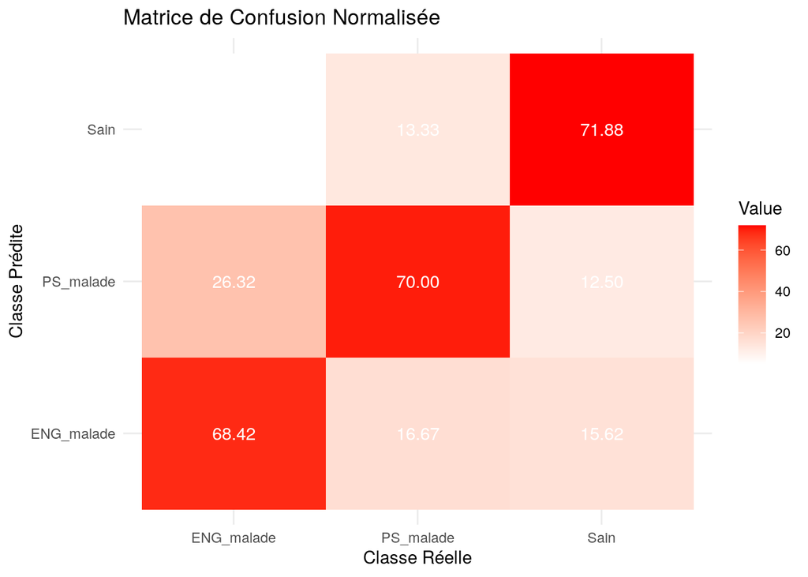

```r
# Visualiser la matrice de confusion normalisée
confusion_df <- melt(confusion.matrix_norm)
colnames(confusion_df) <- c("True", "Predicted", "Value")

ggplot(data = confusion_df, aes(x = True, y = Predicted, fill = Value)) +
  geom_tile() +
  geom_text(aes(label = sprintf("%.2f", Value)), color = "white") +
  scale_fill_gradient(low = "white", high = "red") +
  theme_minimal() +
  labs(title = "Matrice de Confusion Normalisée", x = "Classe Réelle", y = "Classe Prédite")
```

Désormais, on cherche à observer la précision et la sensibilité du modèle :

```r
true_classes <- donnees_mean2$y

# Utiliser la fonction confusionMatrix du package 'caret'
conf_matrix <- confusionMatrix(factor(classes_pred, levels = c("ENG_malade", "PS_malade", "Sain") ), factor(true_classes))

# Récupérer les précisions et rappels par classe
precision <- conf_matrix$byClass[,"Pos Pred Value"]
recall <- conf_matrix$byClass[,"Sensitivity"]

# Créer un dataframe pour la visualisation
metrics_df <- data.frame(
  Classe = c("ENG_malade", "PS_malade", "Sain"),
  Precision = precision,
  sensitivity = recall
)

metrics_df
```

```
##                       Classe Precision sensitivity
## Class: ENG_malade ENG_malade 0.7222222   0.6842105
## Class: PS_malade   PS_malade 0.6000000   0.7000000
## Class: Sain             Sain 0.7931034   0.7187500
```

La précision mesure la proportion des prédictions positives qui sont correctes. La sensibilité mesure la capacité du modèle à détecter les vrais positifs.

Nous pouvons donc dire que le modèle est satisfaisant (environ 70% de bonne modélisation). Le point visiblement négatif est que pour 26% des élevages que nous avons classé en “ENG_malade”, le modèle les prédit en “PS_malade”.

On rappelle que les classes “ENG_malade” et “PS_malade” n’indiquent pas un élevage 100% malade mais indiquent uniquement une tendance des porcs à tousser et/ou à éternuer plus que la moyenne des élevages.

Reste à faire l’interprétation des résultats de la régression logistique multinomiale (de combien est-ce qu’une variable augmente la probabilité à être malade, etc…)